# ERP model

## Coulson et al

```r
# This is Coulson et al
write("Coulson et al", stderr())
coulagree.df = subset(couldf,  str_detect(Condition,"(SING|PLUR)") )
verbpos = which(coulagree.df$wordcat == "VERBT")
wordcatsamelen = which(coulagree.df$wordcat!=coulagree.df$wordcat[1])[1]-1
verb.df = coulagree.df[verbpos,] #  verb
postverbcoul.df = coulagree.df[verbpos + wordcatsamelen,] # position after verb
postverbcoul.df=postverbcoul.df[!is.na(postverbcoul.df$Condition),]

postverbcoul.df = cbind(Probability="",Number="",Agreement="",postverbcoul.df)
cond = str_split_fixed(postverbcoul.df$Condition,";",2)
postverbcoul.df$Number = cond[,1]
postverbcoul.df$Agreement = cond[,2]
postverbcoul.df$Number = factor(postverbcoul.df$Number,labels=c("Singular"))
postverbcoul.df$Agreement = factor(postverbcoul.df$Agreement,labels=c("Control","Violation"))
postverbcoul.df$Probability=NA
postverbcoul.df$Probability[postverbcoul.df$Agreement=="Violation" & str_detect(postverbcoul.df$coul,"vcoul1")] = "Improbable"
postverbcoul.df$Probability[postverbcoul.df$Agreement=="Violation" & str_detect(postverbcoul.df$coul,"vcoul2")] = "Probable"
postverbcoul.df$Probability[postverbcoul.df$Agreement=="Control" & str_detect(postverbcoul.df$coul,"vcoul2")] = "Improbable"
postverbcoul.df$Probability[postverbcoul.df$Agreement=="Control" & str_detect(postverbcoul.df$coul,"vcoul1")] = "Probable"
postverbcoul.df$Probability=factor(postverbcoul.df$Probability)

xtabs(~ Agreement +Probability,postverbcoul.df)
```

```
##            Probability
## Agreement   Improbable Probable
##   Control          600     2400
##   Violation        600     2400
```

```r
print(head(postverbcoul.df[postverbcoul.df$measure=="target",c("word","wordcat","Condition","Example","tick")])) # check
```

```
##      word wordcat Condition                               Example tick
## 157   -ss      SS SING;CONT          the boy take -ss a stick . .    4
## 391  wine   NOUNI PLUR;CONT       the father -s taste wine -s . .    5
## 612     a     DET SING;VIOL            the mother push a kite . .    4
## 846   the     DET PLUR;CONT          the wife -s take the toy . .    5
## 1054  -ss      SS SING;CONT  the brother taste -ss the tea -s . .    4
## 1301  the     DET PLUR;CONT        the clerk -s drink the tea . .    5
```

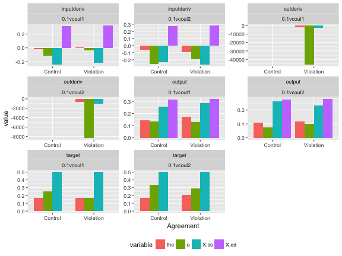

```r
showWordOutError("the,a,X.ss,X.ed",c("Agreement","measure","coul"),postverbcoul.df)
```

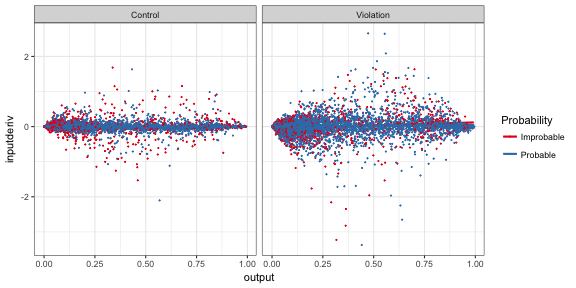

```r
corrHiddenOutputInputDeriv(postverbcoul.df,"Probability", "Agreement")
```

```r
# make erp figure with different measures
mapping = aes(x=depth, y=value, colour = Agreement,linetype=Probability)
coulnorawpostverbnotargout.df=removeWordsDrawERP(postverbcoul.df,mapping)
```

```
## [1] 6
```

```r
interactionText="NO TEXT"
modellist2 = list()

# get example for table
agreeinputword = subset(coulnorawpostverbnotargout.df,measure == mainMeasure  & layer == "word")
exampleTable = agreeinputword[1:4,c("Number","Agreement","Example")]
tabletext = kable(exampleTable,format="latex",row.names=FALSE)
print(exampleTable)
```

```
##        Number Agreement                          Example
## 159 Singular2   Control     the boy take -ss a stick . .
## 393 Singular1   Control  the father -s taste wine -s . .
## 614 Singular2 Violation       the mother push a kite . .
## 848 Singular1   Control     the wife -s take the toy . .
```

```r
coulagreeinput  = subset(coulnorawpostverbnotargout.df,measure == mainMeasure & layer %in% c("word",p600layer) )

if (nlevels(adultdata.df$sub) > 4){ # do mixed with more than 9 subj

  coulagreeinput$cplural = ifelse(coulagreeinput$Number=="Plural",0.5,-0.5)
  coulagreeinput$cviolation = ifelse(coulagreeinput$Agreement=="Violation",0.5,-0.5)
  coulagreeinput$cp6layer = ifelse(coulagreeinput$layer==p600layer,0.5,-0.5)
  coulagreeinput$cprob = ifelse(coulagreeinput$Probability=="Probable",0.5,-0.5)

  #- cviolation:cp6layer:cprob  -cviolation:cp6layer - cviolation:cprob - cp6layer:cprob - cp6layer
  # this is the main mixed model with centered variables
    randomeff = paste(" + (1 + cviolation + cprob |sub)")  #Agreement * layer
      if (noslopes){ randomeff = " + (1 | sub)"}
  formu = as.formula(paste(dependMeasure,"~ cviolation*cp6layer*cprob",randomeff))
  omnimodel = lmer(formu, coulagreeinput,control=lmerControl(optimizer = "bobyqa",optCtrl=list(maxfun=50000)))
  print(summary(omnimodel))
  modellist2 = modelComparison(omnimodel) # create anova table
  # this model is for posthocs
  formu2 = as.formula(paste(dependMeasure,"~ Probability*layer",randomeff))
  omnimodelFactor = lmer(formu2, coulagreeinput)
#  print(summary(omnimodelFactor))
  model.lsmobj <- lsmeans(omnimodelFactor, ~ Probability | layer)
  posthocs = summary(as.glht(pairs(model.lsmobj)))
  print(posthocs)
  interactionText = printInteraction(posthocs)

}
```

```
## Linear mixed model fit by REML ['lmerMod']
## Formula:
## abssum ~ cviolation * cp6layer * cprob + (1 + cviolation + cprob |
##     sub)
##    Data: coulagreeinput
## Control: lmerControl(optimizer = "bobyqa", optCtrl = list(maxfun = 50000))
##
## REML criterion at convergence: 5029.4
##
## Scaled residuals:
##     Min      1Q  Median      3Q     Max
## -2.1148 -0.3718 -0.0235  0.1309  6.6473
##
## Random effects:
##  Groups   Name        Variance  Std.Dev. Corr
##  sub      (Intercept) 0.0988485 0.31440
##           cviolation  0.0003622 0.01903  -1.00
##           cprob       0.2684028 0.51808  -1.00  1.00
##  Residual             3.8215845 1.95489
## Number of obs: 1200, groups:  sub, 10
##
## Fixed effects:
##                           Estimate Std. Error t value
## (Intercept)                 2.8428     0.1219  23.320
## cviolation                  1.8140     0.1412  12.846
## cp6layer                    2.3738     0.1411  16.825
## cprob                      -1.2622     0.2162  -5.838
## cviolation:cp6layer         2.6469     0.2822   9.381
## cviolation:cprob           -0.1361     0.2822  -0.482
## cp6layer:cprob             -2.0513     0.2822  -7.270
## cviolation:cp6layer:cprob  -0.5235     0.5643  -0.928
##
## Correlation of Fixed Effects:
##             (Intr) cviltn cp6lyr cprob  cvlt:6 cvltn: cp6ly:
## cviolation  -0.035
## cp6layer     0.000  0.000
## cprob       -0.845  0.032  0.000
## cvltn:cp6ly  0.000  0.000  0.000  0.000
## cviltn:cprb  0.000 -0.599  0.000  0.000  0.000
## cp6lyr:cprb  0.000  0.000 -0.600  0.000  0.000  0.000
## cvltn:cp6l:  0.000  0.000  0.000  0.000 -0.600  0.000  0.000
## [1] "remove . ~ . -  cviolation:cp6layer:cprob "
```

```
## refitting model(s) with ML (instead of REML)
```

```
## Data: coulagreeinput
## Models:
## model2: abssum ~ cviolation + cp6layer + cprob + (1 + cviolation + cprob |
## model2:     sub) + cviolation:cp6layer + cviolation:cprob + cp6layer:cprob
## model: abssum ~ cviolation * cp6layer * cprob + (1 + cviolation + cprob |
## model:     sub)
##        Df    AIC    BIC  logLik deviance  Chisq Chi Df Pr(>Chisq)
## model2 14 5046.5 5117.8 -2509.2   5018.5
## model  15 5047.6 5124.0 -2508.8   5017.6 0.8653      1     0.3523
## [1] "########## Above comparison for  cviolation:cp6layer:cprob "
## [1] "remove . ~ . -  cp6layer:cprob "
```

```
## refitting model(s) with ML (instead of REML)
```

```
## Data: coulagreeinput
## Models:
## model2: abssum ~ cviolation + cp6layer + cprob + (1 + cviolation + cprob |
## model2:     sub) + cviolation:cp6layer + cviolation:cprob
## model: abssum ~ cviolation + cp6layer + cprob + (1 + cviolation + cprob |
## model:     sub) + cviolation:cp6layer + cviolation:cprob + cp6layer:cprob
##        Df    AIC    BIC  logLik deviance  Chisq Chi Df Pr(>Chisq)
## model2 13 5096.5 5162.6 -2535.2   5070.5
## model  14 5046.5 5117.8 -2509.2   5018.5 51.973      1  5.627e-13 ***
## ---
## Signif. codes:  0 '***' 0.001 '**' 0.01 '*' 0.05 '.' 0.1 ' ' 1
## [1] "########## Above comparison for  cp6layer:cprob  *** "
## [1] "remove . ~ . -  cviolation:cprob "
```

```
## refitting model(s) with ML (instead of REML)
```

```
## Data: coulagreeinput
## Models:
## model2: abssum ~ cviolation + cp6layer + cprob + (1 + cviolation + cprob |
## model2:     sub) + cviolation:cp6layer
## model: abssum ~ cviolation + cp6layer + cprob + (1 + cviolation + cprob |
## model:     sub) + cviolation:cp6layer + cviolation:cprob
##        Df    AIC    BIC  logLik deviance  Chisq Chi Df Pr(>Chisq)
## model2 12 5094.7 5155.8 -2535.3   5070.7
## model  13 5096.5 5162.6 -2535.2   5070.5 0.2238      1     0.6362
## [1] "########## Above comparison for  cviolation:cprob "
## [1] "remove . ~ . -  cviolation:cp6layer "
```

```
## refitting model(s) with ML (instead of REML)
```

```
## Data: coulagreeinput
## Models:
## model2: abssum ~ cviolation + cp6layer + cprob + (1 + cviolation + cprob |
## model2:     sub)
## model: abssum ~ cviolation + cp6layer + cprob + (1 + cviolation + cprob |
## model:     sub) + cviolation:cp6layer
##        Df    AIC    BIC  logLik deviance  Chisq Chi Df Pr(>Chisq)
## model2 11 5204.3 5260.3 -2591.2   5182.3
## model  12 5094.7 5155.8 -2535.3   5070.7 111.64      1  < 2.2e-16 ***
## ---
## Signif. codes:  0 '***' 0.001 '**' 0.01 '*' 0.05 '.' 0.1 ' ' 1
## [1] "########## Above comparison for  cviolation:cp6layer  *** "
## [1] "remove . ~ . -  cprob "
```

```
## refitting model(s) with ML (instead of REML)
```

```
## Data: coulagreeinput
## Models:
## model2: abssum ~ cviolation + cp6layer + (1 + cviolation + cprob | sub)
## model: abssum ~ cviolation + cp6layer + cprob + (1 + cviolation + cprob |
## model:     sub)
##        Df    AIC    BIC  logLik deviance Chisq Chi Df Pr(>Chisq)
## model2 10 5218.0 5268.9 -2599.0   5198.0
## model  11 5204.3 5260.3 -2591.2   5182.3 15.68      1  7.501e-05 ***
## ---
## Signif. codes:  0 '***' 0.001 '**' 0.01 '*' 0.05 '.' 0.1 ' ' 1
## [1] "########## Above comparison for  cprob  *** "
## [1] "remove . ~ . -  cp6layer "
```

```
## refitting model(s) with ML (instead of REML)
```

```
## Data: coulagreeinput
## Models:
## model2: abssum ~ cviolation + (1 + cviolation + cprob | sub)
## model: abssum ~ cviolation + cp6layer + (1 + cviolation + cprob | sub)
##        Df    AIC    BIC  logLik deviance  Chisq Chi Df Pr(>Chisq)
## model2  9 5411.5 5457.3 -2696.7   5393.5
## model  10 5218.0 5268.9 -2599.0   5198.0 195.44      1  < 2.2e-16 ***
## ---
## Signif. codes:  0 '***' 0.001 '**' 0.01 '*' 0.05 '.' 0.1 ' ' 1
## [1] "########## Above comparison for  cp6layer  *** "
## [1] "remove . ~ . -  cviolation "
```

```
## refitting model(s) with ML (instead of REML)
```

```
## Data: coulagreeinput
## Models:
## model2: abssum ~ (1 + cviolation + cprob | sub)
## model: abssum ~ cviolation + (1 + cviolation + cprob | sub)
##        Df    AIC    BIC  logLik deviance  Chisq Chi Df Pr(>Chisq)
## model2  8 5432.2 5472.9 -2708.1   5416.2
## model   9 5411.5 5457.3 -2696.7   5393.5 22.738      1  1.857e-06 ***
## ---
## Signif. codes:  0 '***' 0.001 '**' 0.01 '*' 0.05 '.' 0.1 ' ' 1
## [1] "########## Above comparison for  cviolation  *** "
```

```
## Note: df set to 19
```

```
## $`layer = word`
##
##   Simultaneous Tests for General Linear Hypotheses
##
## Linear Hypotheses:
##                            Estimate Std. Error t value Pr(>|t|)
## Improbable - Probable == 0   1.0470     0.2826   3.706   0.0015 **
## ---
## Signif. codes:  0 '***' 0.001 '**' 0.01 '*' 0.05 '.' 0.1 ' ' 1
## (Adjusted p values reported -- single-step method)
##
##
## $`layer = hidden`
##
##   Simultaneous Tests for General Linear Hypotheses
##
## Linear Hypotheses:
##                            Estimate Std. Error t value Pr(>|t|)
## Improbable - Probable == 0   3.0983     0.2826   10.96 1.17e-09 ***
## ---
## Signif. codes:  0 '***' 0.001 '**' 0.01 '*' 0.05 '.' 0.1 ' ' 1
## (Adjusted p values reported -- single-step method)
```

```r
xtabs(~ coul + Agreement, coulagreeinput)
```

```
##            Agreement
## coul        Control Violation
##   0.1vcoul1     480       120
##   0.1vcoul2     120       480
```

```r
xtabs(~ Probability + Agreement, coulagreeinput)
```

```
##             Agreement
## Probability  Control Violation
##   Improbable     120       120
##   Probable       480       480
```

```r
 mapping = aes_string(x="depth", y=dependMeasure, colour = "Probability",linetype="Probability")
  p = drawERP(coulagreeinput,mapping, span=1, timeline.y=4.7)
```

```
## [1] 6
```

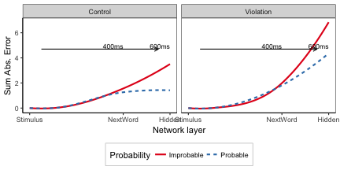

```r
  p = p + facet_wrap(~ Agreement)
  p
```

```r
  if (!noslopes){ # when doing final version, change noslopes to FALSE
    ggsave("img/agreelearn.png",width=figwidth,height=figheight)
  }
```

CUT AND PASTE INTO LATEX DOC click in box and use right arrow to see whole text

```latex
This is an example of the stimuli used in the model.


\begin{tabular}{l|l|l}
\hline
Number & Agreement & Example\\
\hline
Singular2 & Control & the boy take -ss a stick . .\\
\hline
Singular1 & Control & the father -s taste wine -s . .\\
\hline
Singular2 & Violation & the mother push a kite . .\\
\hline
Singular1 & Control & the wife -s take the toy . .\\
\hline
\end{tabular}
The maximal model for the data had random slopes  + (1 + cviolation + cprob |sub)

Mixed Model Results
a main effect of cviolation ($\beta$=1.8, SE=0.14, $\chi^2$(1)=22.74, p<0.001)
a main effect of cp6layer ($\beta$=2.4, SE=0.14, $\chi^2$(1)=195.44, p<0.001)
a main effect of cprob ($\beta$=-1.3, SE=0.22, $\chi^2$(1)=15.68, p<0.001)
an interaction of cviolation:cp6layer ($\beta$=2.6, SE=0.28, $\chi^2$(1)=111.64, p<0.001)
no interaction of cviolation:cprob ($\beta$=-0.14, SE=0.28, $\chi^2$(1)=0.22, p=0.636)
an interaction of cp6layer:cprob ($\beta$=-2.1, SE=0.28, $\chi^2$(1)=51.97, p<0.001)
@@no interaction of cviolation:cp6layer:cprob ($\beta$=-0.52, SE=0.56, $\chi^2$(1)=0.87, p=0.352)
Posthoc tests for each layer
 @@Posthoc: There was a significant difference for layer = word, diff = 1.047, t(19)=3.71, p=0.0015
 @@Posthoc: There was a significant difference for layer = hidden, diff = 3.0983, t(19)=10.97, p<0.001
ratio  layer = hidden   2.95921680993314  rev  0.337927250427654
```

## Rommer Federmeier

```r
# This is Coulson et al
write("Rommer Federmeier", stderr())
romFinalN = subset(rommerdf, wordcat %in% c('NOUNI'))
romFinalN$vrom=NULL
romFinalNtest= subset(romFinalN, Condition %in% c("TEST-UNPRED","TEST-PRED"))

print(head(romFinalNtest[romFinalNtest$measure=="target",c("word","wordcat","Condition","Example","tick")])) # check
```

```
##        word wordcat   Condition
## 14041 water   NOUNI   TEST-PRED
## 14262 water   NOUNI TEST-UNPRED
## 14470   tea   NOUNI   TEST-PRED
## 14678   tea   NOUNI TEST-UNPRED
## 14912 water   NOUNI   TEST-PRED
## 15146 water   NOUNI TEST-UNPRED
##                                           Example tick
## 14041               a wife will sip the water . .    6
## 14262               a wife will sip the water . .    6
## 14470              the clerk -s drink the tea . .    6
## 14678              the clerk -s drink the tea . .    6
## 14912  the brother -s were sip -ing the water . .    8
## 15146  the brother -s were sip -ing the water . .    8
```

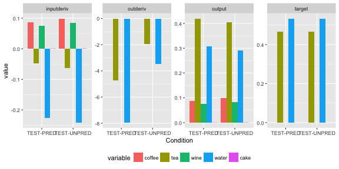

```r
# check that layers are the right size

showWordOutError("coffee,tea,wine,water,cake",c("Condition","measure"),romFinalNtest)
```

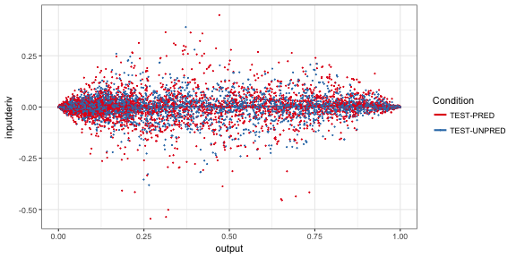

```r
corrHiddenOutputInputDeriv(romFinalNtest,"Condition")
```

```r
# make erp figure with different measures
mapping = aes(x=depth, y=value, colour = Condition,linetype=Condition)
romrawpostverbnotargout.df=removeWordsDrawERP(romFinalNtest,mapping)
```

```
## [1] 6
```

```r
interactionText="NO TEXT"
modellist2 = list()

# # get example for table
romexamdf = subset(rommerdf,measure == mainMeasure  & layer == "word" & tick == 1,c(1:12))
exampleTable = romexamdf[c(1,3,4),c("Condition","Example")]
exampleTable$Condition = factor(exampleTable$Condition,labels =c("Predictable Prime","Target","Unpredictable Prime"))
tabletext = kable(exampleTable,format="latex",row.names=FALSE)
print(exampleTable)
```

```
##                 Condition                                 Example
## 13861   Predictable Prime  a teacher was drink -ing the water . .
## 14082 Unpredictable Prime  a teacher was sniff -ing the water . .
## 14199              Target           a wife will sip the water . .
```

```r
rominput  = subset(romrawpostverbnotargout.df,measure == mainMeasure & layer %in% c("word",p600layer) )
rominput$Prime = factor(rominput$Condition,labels=c("Predictable","Unpredictable"))

if (nlevels(adultdata.df$sub) > 4){ # do mixed with more than 9 subj

  rominput$cpred = ifelse(rominput$Prime=="Predictable",0.5,-0.5)
  rominput$cp6layer = ifelse(rominput$layer==p600layer,0.5,-0.5)

  #- cviolation:cp6layer:cprob  -cviolation:cp6layer - cviolation:cprob - cp6layer:cprob - cp6layer
  # this is the main mixed model with centered variables
    randomeff = paste(" + (1 + Condition*layer |sub)")
      if (noslopes){ randomeff = " + (1 | sub)"}
  formu = as.formula(paste(dependMeasure,"~ cpred*cp6layer",randomeff))
  omnimodel = lmer(formu, rominput,control=lmerControl(optimizer = "bobyqa",optCtrl=list(maxfun=50000)))
  print(summary(omnimodel))
  modellist2 = modelComparison(omnimodel) # create anova table
  # this model is for posthocs
  formu2 = as.formula(paste(dependMeasure,"~ Prime*layer",randomeff))
  omnimodelFactor = lmer(formu2, rominput)
#  print(summary(omnimodelFactor))
  model.lsmobj <- lsmeans(omnimodelFactor, ~ Prime | layer)
  posthocs = summary(as.glht(pairs(model.lsmobj)))
  print(posthocs)
  interactionText = printInteraction(posthocs)

}
```

```
## Linear mixed model fit by REML ['lmerMod']
## Formula: abssum ~ cpred * cp6layer + (1 + Condition * layer | sub)
##    Data: rominput
## Control: lmerControl(optimizer = "bobyqa", optCtrl = list(maxfun = 50000))
##
## REML criterion at convergence: 742
##
## Scaled residuals:
##     Min      1Q  Median      3Q     Max
## -3.3970 -0.4308  0.0071  0.2974  5.5441
##
## Random effects:
##  Groups   Name                             Variance  Std.Dev. Corr
##  sub      (Intercept)                      0.0006176 0.02485
##           ConditionTEST-UNPRED             0.0189776 0.13776   0.82
##           layerhidden                      0.3979248 0.63081  -0.54 -0.87
##           ConditionTEST-UNPRED:layerhidden 0.0485065 0.22024   0.64  0.95
##  Residual                                  0.1829522 0.42773
##
##
##
##
##  -0.97
##
## Number of obs: 600, groups:  sub, 10
##
## Fixed effects:
##                 Estimate Std. Error t value
## (Intercept)     1.386926   0.065255  21.254
## cpred           0.281830   0.084966   3.317
## cp6layer       -0.511371   0.169366  -3.019
## cpred:cp6layer -0.008624   0.098638  -0.087
##
## Correlation of Fixed Effects:
##             (Intr) cpred cp6lyr
## cpred       0.670
## cp6layer    0.905  0.812
## cprd:cp6lyr 0.584  0.634 0.665
## [1] "remove . ~ . -  cpred:cp6layer "
```

```
## refitting model(s) with ML (instead of REML)
```

```
## Data: rominput
## Models:
## model2: abssum ~ cpred + cp6layer + (1 + Condition * layer | sub)
## model: abssum ~ cpred * cp6layer + (1 + Condition * layer | sub)
##        Df    AIC    BIC  logLik deviance  Chisq Chi Df Pr(>Chisq)
## model2 14 755.52 817.08 -363.76   727.52
## model  15 757.20 823.16 -363.60   727.20 0.3232      1     0.5697
## [1] "########## Above comparison for  cpred:cp6layer "
## [1] "remove . ~ . -  cp6layer "
```

```
## refitting model(s) with ML (instead of REML)
```

```
## Data: rominput
## Models:
## model2: abssum ~ cpred + (1 + Condition * layer | sub)
## model: abssum ~ cpred + cp6layer + (1 + Condition * layer | sub)
##        Df    AIC    BIC  logLik deviance  Chisq Chi Df Pr(>Chisq)
## model2 13 763.51 820.67 -368.76   737.51
## model  14 755.52 817.08 -363.76   727.52 9.9857      1   0.001578 **
## ---
## Signif. codes:  0 '***' 0.001 '**' 0.01 '*' 0.05 '.' 0.1 ' ' 1
## [1] "########## Above comparison for  cp6layer  *** "
## [1] "remove . ~ . -  cpred "
```

```
## refitting model(s) with ML (instead of REML)
```

```
## Data: rominput
## Models:
## model2: abssum ~ (1 + Condition * layer | sub)
## model: abssum ~ cpred + (1 + Condition * layer | sub)
##        Df    AIC    BIC  logLik deviance Chisq Chi Df Pr(>Chisq)
## model2 12 779.04 831.80 -377.52   755.04
## model  13 763.51 820.67 -368.76   737.51 17.53      1  2.828e-05 ***
## ---
## Signif. codes:  0 '***' 0.001 '**' 0.01 '*' 0.05 '.' 0.1 ' ' 1
## [1] "########## Above comparison for  cpred  *** "
```

```
## Note: df set to 9
```

```
## $`layer = word`
##
##   Simultaneous Tests for General Linear Hypotheses
##
## Linear Hypotheses:
##                                  Estimate Std. Error t value Pr(>|t|)
## Predictable - Unpredictable == 0  0.28614    0.06586   4.345  0.00186 **
## ---
## Signif. codes:  0 '***' 0.001 '**' 0.01 '*' 0.05 '.' 0.1 ' ' 1
## (Adjusted p values reported -- single-step method)
##
##
## $`layer = hidden`
##
##   Simultaneous Tests for General Linear Hypotheses
##
## Linear Hypotheses:
##                                  Estimate Std. Error t value Pr(>|t|)
## Predictable - Unpredictable == 0   0.2775     0.1223   2.269   0.0495 *
## ---
## Signif. codes:  0 '***' 0.001 '**' 0.01 '*' 0.05 '.' 0.1 ' ' 1
## (Adjusted p values reported -- single-step method)
```

```r
 mapping = aes_string(x="depth", y=dependMeasure, colour = "Prime",linetype="Prime")
  p = drawERP(rominput,mapping, span=1, timeline.y=2)
```

```
## [1] 6
```

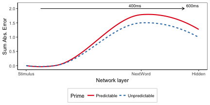

```r
  p
```

```r
  if (!noslopes){ # when doing final version, change noslopes to FALSE
    ggsave("img/rommers.png",width=figwidth,height=figheight)
  }
```

CUT AND PASTE INTO LATEX DOC click in box and use right arrow to see whole text

```latex
This is an example of the stimuli used in the model.


\begin{tabular}{l|l}
\hline
Condition & Example\\
\hline
Predictable Prime & a teacher was drink -ing the water . .\\
\hline
Unpredictable Prime & a teacher was sniff -ing the water . .\\
\hline
Target & a wife will sip the water . .\\
\hline
\end{tabular}
The maximal model for the data had random slopes  + (1 + Condition*layer |sub)

Mixed Model Results
a main effect of cpred ($\beta$=0.28, SE=0.085, $\chi^2$(1)=17.53, p<0.001)
a main effect of cp6layer ($\beta$=-0.51, SE=0.17, $\chi^2$(1)=9.99, p=0.0016)
@@no interaction of cpred:cp6layer ($\beta$=-0.0086, SE=0.099, $\chi^2$(1)=0.32, p=0.570)
Posthoc tests for each layer
 @@Posthoc: There was a significant difference for layer = word, diff = 0.2861, t(9)=4.34, p=0.0019
 @@Posthoc: There was a significant difference for layer = hidden, diff = 0.2775, t(9)=2.27, p=0.0495
ratio  layer = hidden   0.969940580216707  rev  1.03099099099099
```

## Overall accuracy results

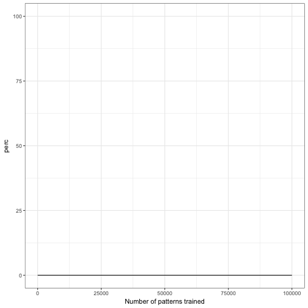

```r
test = read.csv("testdata.csv")
testsum = aggregate(cbind(corr,total) ~ epoch, test, sum)
testsum=rbind(testsum,data.frame(epoch=0,corr=0,total=200))
testsum$perc = 100* testsum$corr/testsum$total
p1=ggplot(testsum,aes(x=epoch,y=perc))+geom_line()+ylim(0,100)
  p1 = p1 + scale_colour_brewer( palette="Set1")
  p1 = p1 + theme_bw() + xlab("Number of patterns trained")
p1
```

```r
paste("@@Test Accuracy ",tail(aggregate(perc ~ epoch, test, mean),1))
```

```
## [1] "@@Test Accuracy  100000" "@@Test Accuracy  0"
```

## Example data for introduction

- These figures below are made up data that help to explain the model
- Word Level: The children went out to …

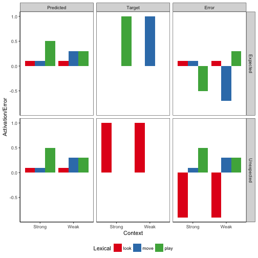

- N400 is sensitive to cloze probabilites of words

## Agreement Lexical Level: The spoilt child throws the toys on the floor

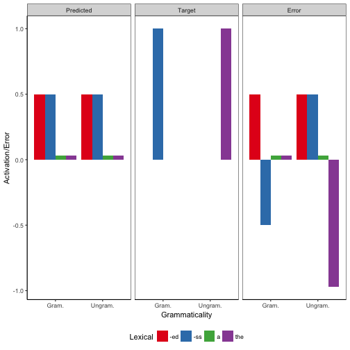

- Syntactic distinctions do not show an N400

## Agreement Syntactic Level: The spoilt child throws the toys on the floor

```
##   Grammaticality Lexical Predicted Target Error Weight NetinputBack
## 1          Gram.     -ss      0.50      1 -0.50      2        -1.00
## 2          Gram.     -ed      0.50      0  0.50      2         1.00
## 3          Gram.     the      0.03      0  0.03     -1        -0.03
## 4          Gram.       a      0.03      0  0.03     -1        -0.03
## 5        Ungram.     -ss      0.50      0  0.50      2         1.00
## 6        Ungram.     -ed      0.50      0  0.50      2         1.00
## 7        Ungram.     the      0.03      1 -0.97     -1         0.97
## 8        Ungram.       a      0.03      0  0.03     -1        -0.03
##   Weight2 NetinputBack2
## 1      -1          0.50
## 2      -1         -0.50
## 3       2          0.06
## 4       2          0.06
## 5      -1         -0.50
## 6      -1         -0.50
## 7       2         -1.94
## 8       2          0.06
```

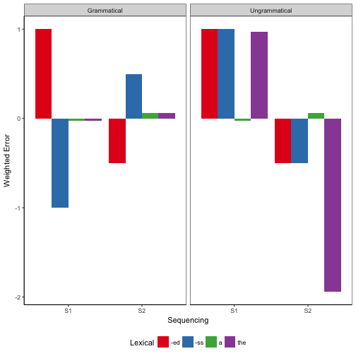

```
##   Grammaticality NetinputBack NetinputBack2 Error
## 1          Gram.        -0.06          0.12  0.18
## 2        Ungram.         2.94         -2.88  5.82
```

## Agreement Wave ERP: The spoilt child throws the toys on the floor

```
## [1] 6
```

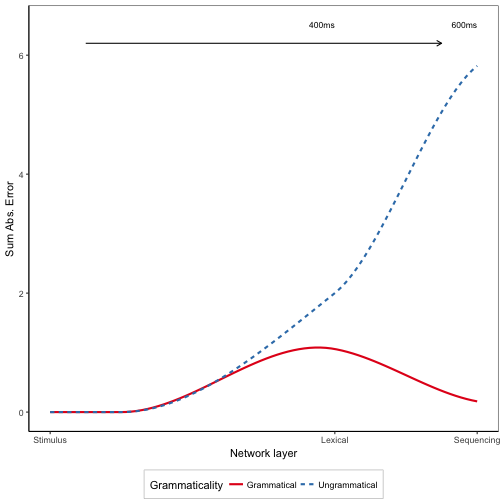

## Draw Sequencing-Hidden Network

```
##   Grammaticality Lexical Predicted Target Error Weight NetinputBack
## 1          Gram.     -ss      0.50      1 -0.50      2        -1.00
## 2          Gram.     -ed      0.50      0  0.50      2         1.00
## 3          Gram.     the      0.03      0  0.03     -1        -0.03
## 4          Gram.       a      0.03      0  0.03     -1        -0.03
## 5        Ungram.     -ss      0.50      0  0.50      2         1.00
## 6        Ungram.     -ed      0.50      0  0.50      2         1.00
## 7        Ungram.     the      0.03      1 -0.97     -1         0.97
## 8        Ungram.       a      0.03      0  0.03     -1        -0.03
##   Weight2 NetinputBack2 Sequencing
## 1      -1          0.50         S1
## 2      -1         -0.50         S1
## 3       2          0.06         S1
## 4       2          0.06         S1
## 5      -1         -0.50         S1
## 6      -1         -0.50         S1
## 7       2         -1.94         S1
## 8       2          0.06         S1
```

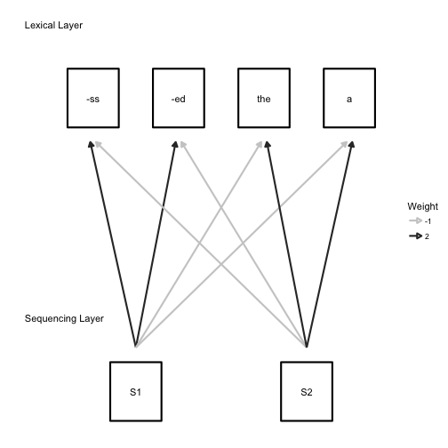

## box diagram

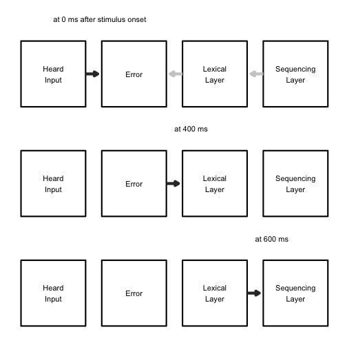

## Word Level

```
## [1] 6
```

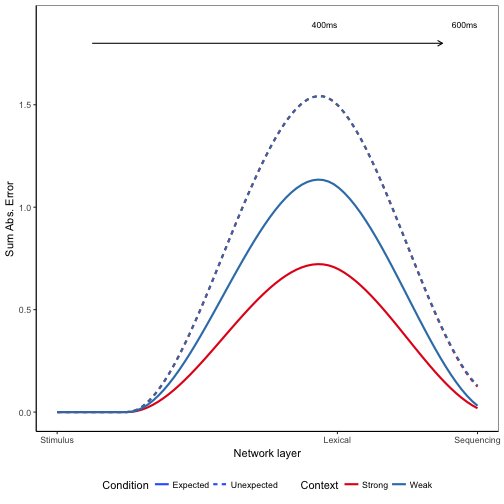

## Draw Network

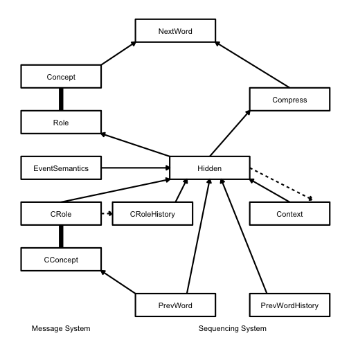